# Introduction to using shiny

2022-06-17

## Outline

- Brief intro to the elements of shiny
- How shiny can help make your work more accessible
- Examples

## shiny

- Framework for making web apps with R code
- Relies on a shiny server that runs R code behind the scenes (CDS has a shinyapps.io plan!)
- Means that you can make web apps with little-to-no knowledge of HTML, CSS or Javascript (unless you want to make things highly personalised)
- Uses reactive programming so that the outputs react the user’s inputs

## Making a shiny app

- The **easiest** way to make a shiny app is to make a new R project from RStudio

[figure not shown]

- The next easiest way is to create a new R script, call is `app.R`, and create your app starting from a snippet

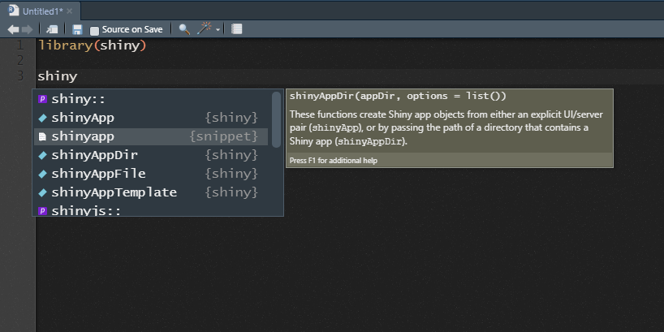

## Components

A shiny app is made up of two parts: the `ui` that defines how it looks and the `server` which defines how it works.

```r
library(shiny)
ui <- fluidPage(

)
server <- function(input, output, session) {

}

shinyApp(ui, server)
```

Content that is added to the UI displays to the user.

```r
library(shiny)
ui <- fluidPage(
  "Hello, CDS!"
)

server <- function(input, output, session) {

}
shinyApp(ui, server)
```

Outputs which are rendered on the server side can be displayed by the ui.

You have to tell the ui what sort of object is being rendered:

- `plotOutput()` ~ `renderPlot()`
- `tableOutput()` ~ `renderTable()`
- `leafletOutput()` ~ `renderLeaflet()`

Many of these are in `{shiny}` but some will be in their respective packages (`{leaflet}` for the last one)

```r
ui <- fluidPage(
  plotOutput("plot")
)
server <- function(input, output, session) {
  output$plot <- renderPlot({
    hist(rnorm(n=20))
  })
}
shinyApp(ui, server)
```

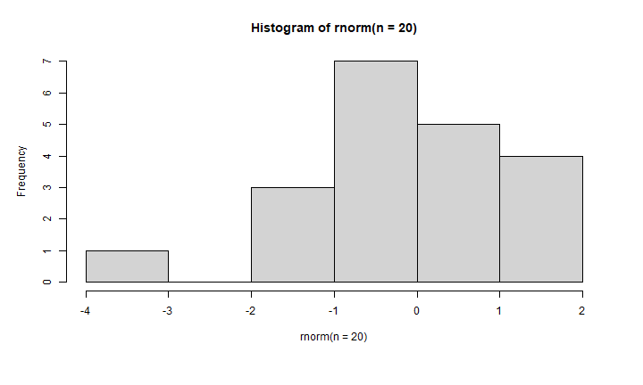

```r
ui <- fluidPage(
  plotOutput("plot")
)
server <- function(input, output, session) {
  output$plot <- renderPlot({
    hist(rnorm(n=20))
  })
}
shinyApp(ui, server)
```

## Adding controls

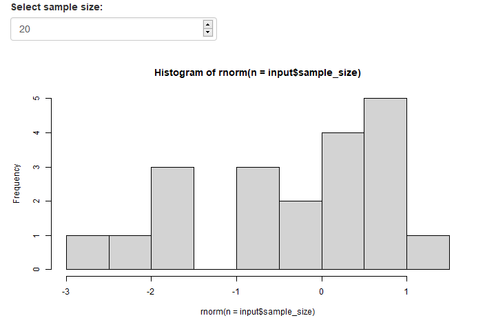

```r
ui <- fluidPage(
  numericInput("sample_size", "Select sample size:", value=20),
  plotOutput("plot")
)

server <- function(input, output, session) {
  output$plot <- renderPlot({
    hist(rnorm(n=input$sample_size))
  })
}

shinyApp(ui, server)
```

## There are lots of ways that you can get inputs from your users

```r
funs <- ls("package:shiny")
funs[grepl("input$", tolower(funs)) & !grepl("update", tolower(funs))]
```

```
##  [1] "checkboxGroupInput"      "checkboxInput"
##  [3] "dateInput"               "dateRangeInput"
##  [5] "fileInput"               "numericInput"
##  [7] "passwordInput"           "restoreInput"
##  [9] "selectInput"             "selectizeInput"
## [11] "sliderInput"             "snapshotPreprocessInput"
## [13] "textAreaInput"           "textInput"
## [15] "varSelectInput"          "varSelectizeInput"
```

(Also see `{shinyWidgets}` for some fun input options)

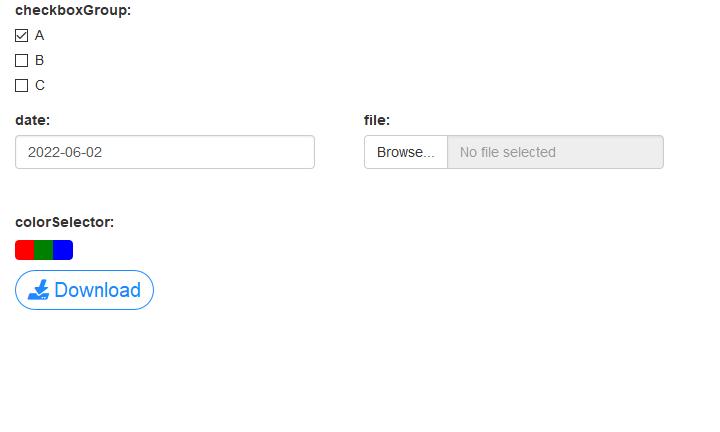

```r
ui <- fluidPage(
  checkboxGroupInput('checkboxGroupInput', 'checkboxGroup:', choices=LETTERS[1:3], selected="A"),
  splitLayout(dateInput("dateInput", "date:"), fileInput("fileInput", "file:")),
  shinyWidgets::colorSelectorInput("colorSelectorInput", "colorSelector:", c("red", "green", "blue"), "red"),
  shinyWidgets::downloadBttn("downloadBttn")
)
server <- function(input, output, session) {
}
shinyApp(ui, server)
```

## shiny apps can make your work more accessible

- For new methods and models, R packages can work well for regular useRs but not necessarily others
- Some results are complex and hard to show all the possible way data could be visusalised in a single paper

## shiny maps can make your work more accessible

### circacompare

App that allows users to upload their data and fit a nonlinear model (using `nls()`) that estimates differences in circadian characteristics between two groups.

https://rwparsons.shinyapps.io/circacompare/

Most use the [R package](https://cran.r-project.org/web/packages/circacompare/index.html) but sometimes, they will say that they specifically used the shiny app.Liu, Xianhui, et al. “Hexosamine biosynthetic pathway integrates circadian and metabolic signals to regulate daily rhythms in protein O-linked N-acetylglucosaminylation.” *bioRxiv* (2020).

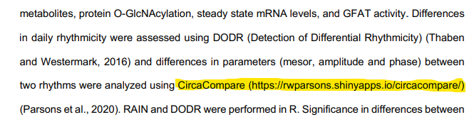

## shiny maps can make your work more accessible

### ECOHIS to CHU9D mapping

- Usually this type of work has a linear model and equation in paper
- This work had many models and variable levels of performance (and assumption destruction)
- App gives the user the ability to get predictions with new data and inspect diagnostic plots

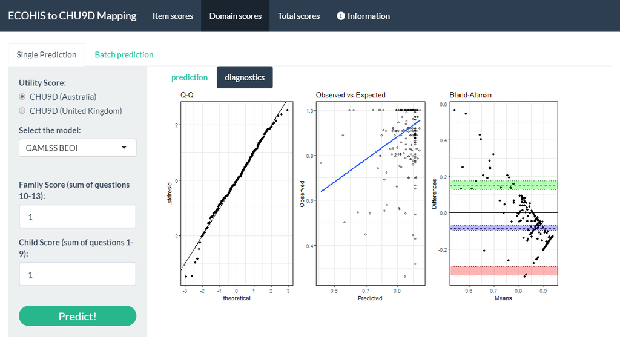

## shiny maps can make your work more accessible

### iTRAQI

[figure not shown]

This app visualises inequity in access to traumatic brain injury care across QLD.

https://access.healthequity.link/

[figure not shown]

## Resources

[figure not shown]

[figure not shown]

https://rwparsons.github.io/interactive-maps/

## Thank you

[figure not shown]

[figure not shown]

@Rex_Parsons8

@RWParsons

Slides were made using `ioslides_presentation` in RMarkdown